# Session 6: Data Wrangling

Aje Joshua Ayodele

27 October 2019

## Introduction

Data wrangling (used interchangeably with data munging) involves tidying your data, manipulating it, and if necessary, creating new variables from the current data to get your data in a proper form for further analysis by you or by others. In this session, we will work with the WHO dataset `tidyr::who` which contains tuberculosis cases broken down by year, country, age, gender, and diagnosis method.

This session is heavily inspired by the `tidy data` section of Hadley Wickham’s R for Data Science book.

*Objective*: To compute the total number of cases of TB for each country, year, and sex. To make an informative visualisation of the data.

For this session, We make use of functions from a couple of `tidyverse` packages.

```r
#load libraries
library(tidyverse)
```

### Data Inspection

After loading the data, the first step in data wrangling is to inspect the data.

```r
#load the data
data(who)

#check the first few rows to initialize the data
head(who)
```

```
## # A tibble: 6 x 60
##   country iso2  iso3   year new_sp_m014 new_sp_m1524 new_sp_m2534
##   <chr>   <chr> <chr> <int>       <int>        <int>        <int>
## 1 Afghan~ AF    AFG    1980          NA           NA           NA
## 2 Afghan~ AF    AFG    1981          NA           NA           NA
## 3 Afghan~ AF    AFG    1982          NA           NA           NA
## 4 Afghan~ AF    AFG    1983          NA           NA           NA
## 5 Afghan~ AF    AFG    1984          NA           NA           NA
## 6 Afghan~ AF    AFG    1985          NA           NA           NA
## # ... with 53 more variables: new_sp_m3544 <int>, new_sp_m4554 <int>,
## #   new_sp_m5564 <int>, new_sp_m65 <int>, new_sp_f014 <int>,
## #   new_sp_f1524 <int>, new_sp_f2534 <int>, new_sp_f3544 <int>,
## #   new_sp_f4554 <int>, new_sp_f5564 <int>, new_sp_f65 <int>,
## #   new_sn_m014 <int>, new_sn_m1524 <int>, new_sn_m2534 <int>,
## #   new_sn_m3544 <int>, new_sn_m4554 <int>, new_sn_m5564 <int>,
## #   new_sn_m65 <int>, new_sn_f014 <int>, new_sn_f1524 <int>,
## #   new_sn_f2534 <int>, new_sn_f3544 <int>, new_sn_f4554 <int>,
## #   new_sn_f5564 <int>, new_sn_f65 <int>, new_ep_m014 <int>,
## #   new_ep_m1524 <int>, new_ep_m2534 <int>, new_ep_m3544 <int>,
## #   new_ep_m4554 <int>, new_ep_m5564 <int>, new_ep_m65 <int>,
## #   new_ep_f014 <int>, new_ep_f1524 <int>, new_ep_f2534 <int>,
## #   new_ep_f3544 <int>, new_ep_f4554 <int>, new_ep_f5564 <int>,
## #   new_ep_f65 <int>, newrel_m014 <int>, newrel_m1524 <int>,
## #   newrel_m2534 <int>, newrel_m3544 <int>, newrel_m4554 <int>,
## #   newrel_m5564 <int>, newrel_m65 <int>, newrel_f014 <int>,
## #   newrel_f1524 <int>, newrel_f2534 <int>, newrel_f3544 <int>,
## #   newrel_f4554 <int>, newrel_f5564 <int>, newrel_f65 <int>
```

```r
#check to see if there are NA's
sum(is.na(who))
```

```
## [1] 329394
```

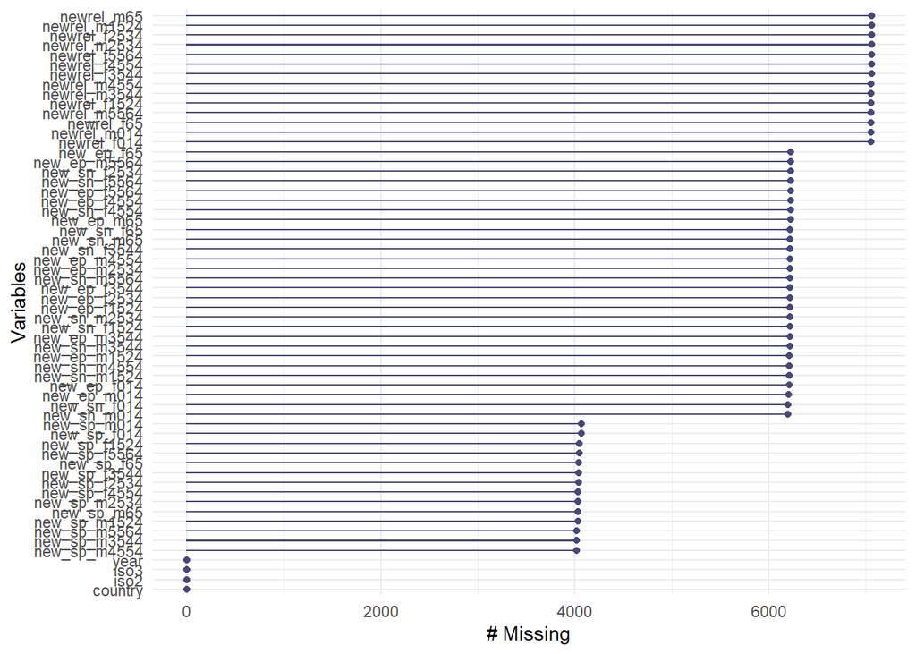

```r
#plot to see columns with missing values
#install.packages("naniar")
library(naniar)
gg_miss_var(who)
```

As with most real-life data, this data is very messy, which makes it difficult to start working with it in this form. What are the first few things we notice?

- There are some redundant variables i.e., `country`, `iso2`, `iso3` represent the same thing
- There are a lot of missing values in the columns
- Given the pattern in the variable names (e.g. `new_sp_m014`, `new_sn_m014`, `new_ep_m014`, `newrel_m014`), these variables seem to be categories/ values than variables

### Data Structuring

We begin tidying the data by checking for the columns that aren’t variables. The three golden rules of tidy data are:

- Each variable must have its own column
- Each observation must have its own row
- Each value must have its own cell

For illustration, this is a classic example of a dataset where the columns `1999` and `2000` are meant to be values and not variables. To tidy it, we gather `1999` and `2000` into a new column `year`.

```r
table1 <- tibble(country = c("Brazil", "Nigeria", "China"),
                 "1999" = c(32134, 78737, 182349),
                 "2000" = c(56823, 95275, 190620))

table2 <- table1 %>% gather(key = "year", value = "pop", "1999", "2000")

table2 %>% filter(year == "2000")
```

```
## # A tibble: 3 x 3
##   country year     pop
##   <chr>   <chr>  <dbl>
## 1 Brazil  2000   56823
## 2 Nigeria 2000   95275
## 3 China   2000  190620
```

```r
table2 %>% filter(country == "Nigeria")
```

```
## # A tibble: 2 x 3
##   country year    pop
##   <chr>   <chr> <dbl>
## 1 Nigeria 1999  78737
## 2 Nigeria 2000  95275
```

```r
#to undo table2, we use spread
table2 %>% spread(key = "year", value = "pop")
```

```
## # A tibble: 3 x 3
##   country `1999` `2000`
##   <chr>    <dbl>  <dbl>
## 1 Brazil   32134  56823
## 2 China   182349 190620
## 3 Nigeria  78737  95275
```

We use `gather()` when we notice that we have columns that are not variables. Therefore, we gather all the columns from `new_sp_m014` to `newrel_f65` into a new column with the generic name `key` — for lack of knowledge of what these values represent.

```r
who1 <- who %>%
  gather(key = "key", value = "cases", 5:60)

#check the dimension of the new dataset
dim(who1)
```

```
## [1] 405440      6
```

Do you notice that the new dataset `who1` has more rows and less columns than the previous one? What do you think is the reason for this?

### Data Cleaning

Next, we see that there are a lot of missing `cases`;for now we filter them out so we can focus on the non-missing values.

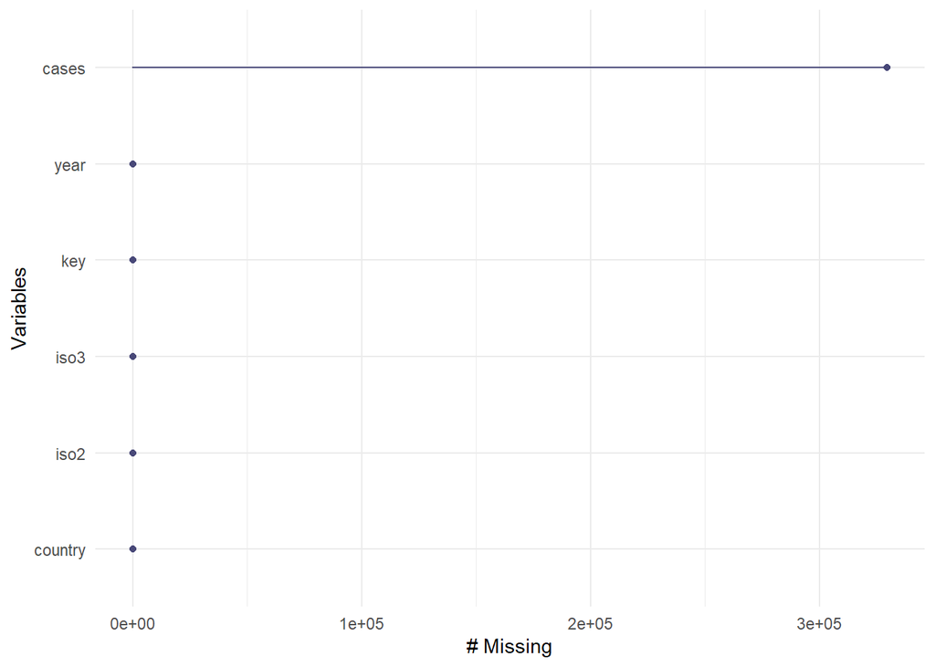

```r
#check for columns with missing values
#colSums(is.na(who1))
gg_miss_var(who1) #plot of variables with no of mmissing values
```

```r
miss_var_summary(who1) #summary of missing values per variable
```

```
## # A tibble: 6 x 3
##   variable n_miss pct_miss
##   <chr>     <int>    <dbl>
## 1 cases    329394     81.2
## 2 country       0      0
## 3 iso2          0      0
## 4 iso3          0      0
## 5 year          0      0
## 6 key           0      0
```

```r
#filter out missing values
who1 <- who1 %>% #overide the previous `who1`
  filter(!is.na(cases)) #note: `filter()` is used to manipulate rows

#we can gather and filter at once
who %>%
  gather(key = "key", value = "cases", new_sp_m014:newrel_f65) %>%
  filter(!is.na(cases))
```

```
## # A tibble: 76,046 x 6
##    country     iso2  iso3   year key         cases
##    <chr>       <chr> <chr> <int> <chr>       <int>
##  1 Afghanistan AF    AFG    1997 new_sp_m014     0
##  2 Afghanistan AF    AFG    1998 new_sp_m014    30
##  3 Afghanistan AF    AFG    1999 new_sp_m014     8
##  4 Afghanistan AF    AFG    2000 new_sp_m014    52
##  5 Afghanistan AF    AFG    2001 new_sp_m014   129
##  6 Afghanistan AF    AFG    2002 new_sp_m014    90
##  7 Afghanistan AF    AFG    2003 new_sp_m014   127
##  8 Afghanistan AF    AFG    2004 new_sp_m014   139
##  9 Afghanistan AF    AFG    2005 new_sp_m014   151
## 10 Afghanistan AF    AFG    2006 new_sp_m014   193
## # ... with 76,036 more rows
```

```r
#count number of cases for each keys
who1 %>%
  count(key)
```

```
## # A tibble: 56 x 2
##    key              n
##    <chr>        <int>
##  1 new_ep_f014   1032
##  2 new_ep_f1524  1021
##  3 new_ep_f2534  1021
##  4 new_ep_f3544  1021
##  5 new_ep_f4554  1017
##  6 new_ep_f5564  1017
##  7 new_ep_f65    1014
##  8 new_ep_m014   1038
##  9 new_ep_m1524  1026
## 10 new_ep_m2534  1020
## # ... with 46 more rows
```

Now we trun our attention to what the values of the `key` mean. The data dictionary tells us that:

- The first three letters indicate whether the TB cases are old or new
- The next two letters describe the type of TB:
  - `sp` — smear positive cases of pulmonary TB
  - `sn` — smear negative cases of pulmonary TB
  - `ep` — cases of extrapulmonary TB
  - `rel` — cases of relapse
- The sixth letter indicates the sex of the TB patients (m or f)
- The remaining numbers tells us the age group of the patients
  - 014 = 0 - 14
  - 1524 = 15 - 24
  - 2534 = 25 - 34
  - 3544 = 35 - 44
  - 4554 = 45 - 54
  - 5564 = 55 - 64
  - 65 = 65 or older

This tells us we need to separate the key column into individual columns. We could easily do this by breaking up the column at the position where there is an underscore ’_’. In order to do that, we first have to ensure that the names follow the same pattern, i.e. converting `newrel` to `new_rel`. We can do this using the `str_replace` function from the `stringr` package.

```r
library(stringr)

#replace "newrel" with "new_rel"
who2 <- who1 %>% mutate(key = str_replace(key, "newrel", "new_rel"))

#confirm replacement
tail(who2)
```

```
## # A tibble: 6 x 6
##   country                            iso2  iso3   year key         cases
##   <chr>                              <chr> <chr> <int> <chr>       <int>
## 1 Venezuela (Bolivarian Republic of) VE    VEN    2013 new_rel_f65   402
## 2 Viet Nam                           VN    VNM    2013 new_rel_f65  3110
## 3 Wallis and Futuna Islands          WF    WLF    2013 new_rel_f65     2
## 4 Yemen                              YE    YEM    2013 new_rel_f65   360
## 5 Zambia                             ZM    ZMB    2013 new_rel_f65   669
## 6 Zimbabwe                           ZW    ZWE    2013 new_rel_f65   725
```

Now we can separate the values of `key` using `separate()`.

```r
who3 <- who2 %>% separate(key, into = c("new", "type", "sexage"), sep = "_")
```

Next, we separate `sexage` into `sex` and `age` by splitting it after the first character.

```r
who4 <- who3 %>%
  separate(sexage, c("sex", "age"), sep = 1)
```

We can now drop redundant variables using `select()`.

```r
#drop iso2, iso3, new
who5 <- who4 %>% select(-contains('iso'), -new) %>% # 'select' is used to manipulate columns just as 'filter' is used to manipulate rows
  rename(age_group = age)

#other ways of selecting: 1
who6 <- who4 %>% select(-c(iso2, iso3, new)) %>% # 'select' is used to manipulate columns just as 'filter' is used to manipulate rows
  rename(age_group = age)

#other ways of selecting: 2
who7 <- who4 %>% select(-starts_with('iso'), -new) %>% # 'select' is used to manipulate columns just as 'filter' is used to manipulate rows
  rename(age_group = age)

#compare the datasets
identical(who5, who6)
```

```
## [1] TRUE
```

```r
identical(who5, who7)
```

```
## [1] TRUE
```

```r
#check first few rows
head(who7)
```

```
## # A tibble: 6 x 6
##   country      year type  sex   age_group cases
##   <chr>       <int> <chr> <chr> <chr>     <int>
## 1 Afghanistan  1997 sp    m     014           0
## 2 Afghanistan  1998 sp    m     014          30
## 3 Afghanistan  1999 sp    m     014           8
## 4 Afghanistan  2000 sp    m     014          52
## 5 Afghanistan  2001 sp    m     014         129
## 6 Afghanistan  2002 sp    m     014          90
```

The `who` dataset is now tidy!

It is possible to do all these steps at once using the pipe operator:

```r
who %>%
  gather(key = "key", value = "cases", new_sp_m014:newrel_f65) %>%
  filter(!is.na(cases)) %>%
  mutate(key = str_replace(key, "newrel", "new_rel")) %>%
  separate(key, c("new", "type", "sexage"), sep = "_") %>%
  separate(sexage, c("sex", "age"), sep = 1) %>%
  select(-contains("iso"), -new) %>%
  rename(age_group = age)
```

```
## # A tibble: 76,046 x 6
##    country      year type  sex   age_group cases
##    <chr>       <int> <chr> <chr> <chr>     <int>
##  1 Afghanistan  1997 sp    m     014           0
##  2 Afghanistan  1998 sp    m     014          30
##  3 Afghanistan  1999 sp    m     014           8
##  4 Afghanistan  2000 sp    m     014          52
##  5 Afghanistan  2001 sp    m     014         129
##  6 Afghanistan  2002 sp    m     014          90
##  7 Afghanistan  2003 sp    m     014         127
##  8 Afghanistan  2004 sp    m     014         139
##  9 Afghanistan  2005 sp    m     014         151
## 10 Afghanistan  2006 sp    m     014         193
## # ... with 76,036 more rows
```

### Analysis

We compute the total number of cases of TB for each country, year, and sex. We visualize our results.

```r
#compute total cases by country, year and sex
who8 <- who5 %>%
  group_by(country, year, sex) %>%
  summarize_at("cases", sum) %>%
  ungroup()

#check data for a particular country
head(who8 %>% filter(country == "Germany"))
```

```
## # A tibble: 6 x 4
##   country  year sex   cases
##   <chr>   <int> <chr> <int>
## 1 Germany  1995 f      1140
## 2 Germany  1995 m      2712
## 3 Germany  1996 f      1157
## 4 Germany  1996 m      2523
## 5 Germany  1997 f      1018
## 6 Germany  1997 m      2328
```

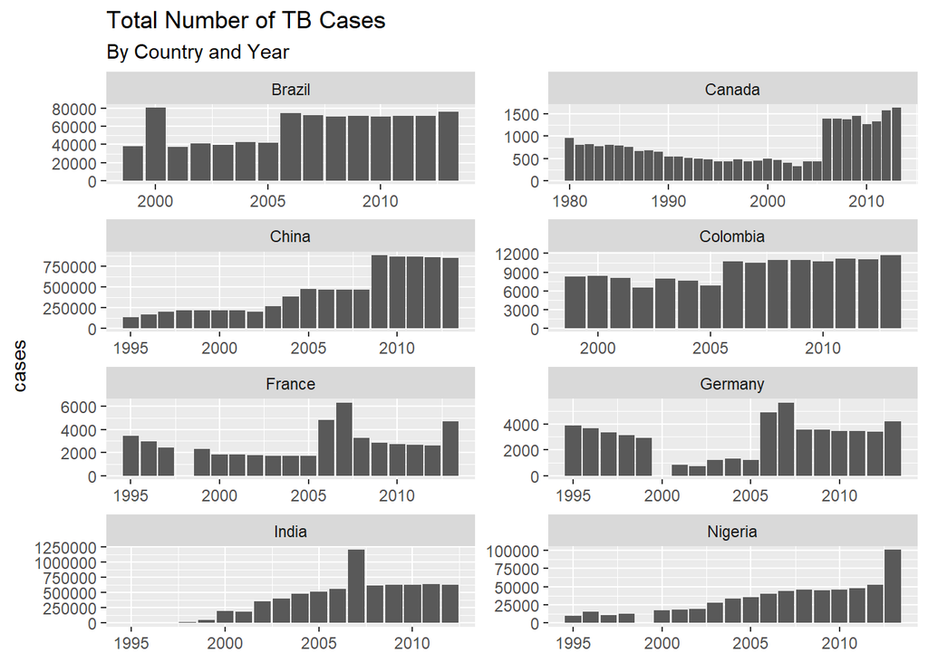

```r
#total cases by country and year
who8 %>%
  filter(country %in% c("Germany", "Brazil", "Nigeria", "Colombia", "India", "Canada", "China", "France")) %>%
  ggplot(aes(x = year, y = cases)) +
  geom_col() +
  labs(title = "Total Number of TB Cases",
      subtitle = "By Country and Year",
      x = NULL) +
  facet_wrap(~ country, scales = "free", ncol = 2)
```

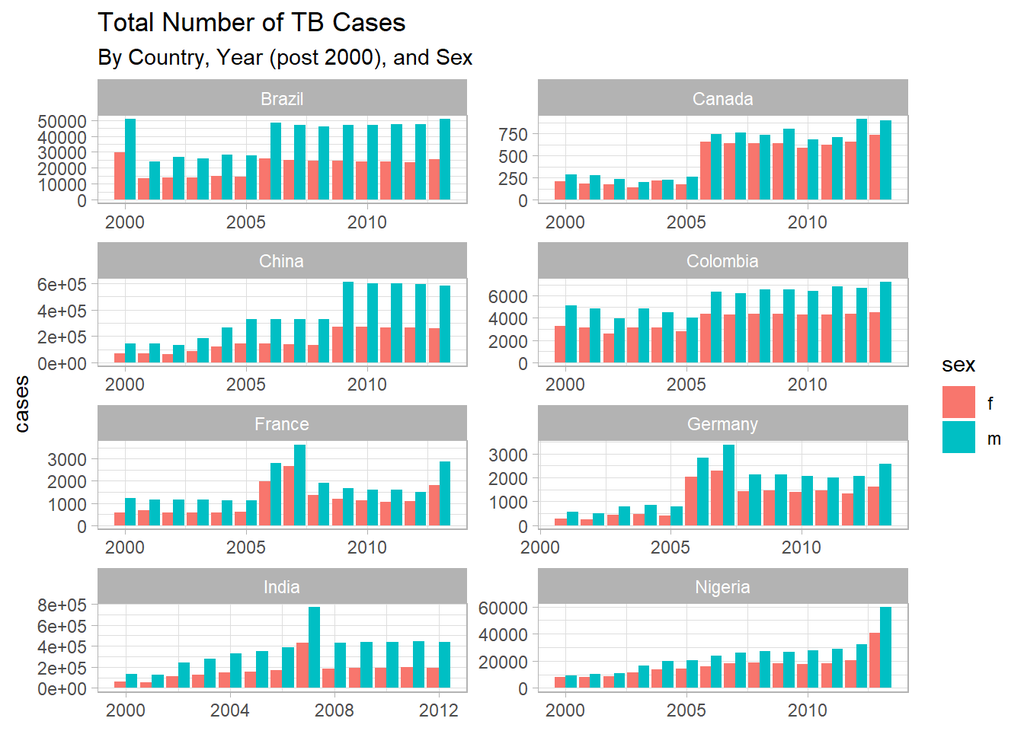

```r
#total cases by country, year (after 2000) and sex
who8 %>%
  filter(country %in% c("Germany", "Brazil", "Nigeria", "Colombia", "India", "Canada", "China", "France"),
         year >= 2000) %>%
  ggplot(aes(x = year, y = cases, fill = sex)) +
  geom_col(position = "dodge") +
  labs(title = "Total Number of TB Cases",
      subtitle = "By Country, Year (post 2000), and Sex",
      x = NULL) +
  facet_wrap(~ country, scales = "free", ncol = 2) +
  theme_light()
```

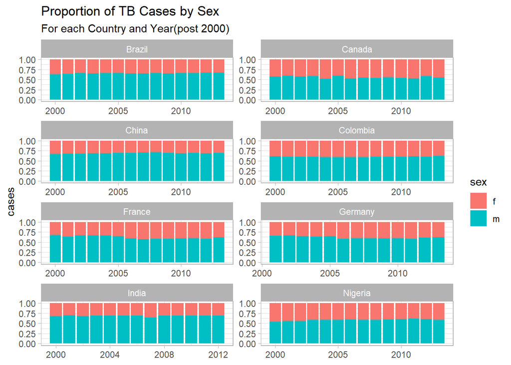

```r
#Proportion of cases by sex for each country (after 2000) and year
who8 %>%
  filter(country %in% c("Germany", "Brazil", "Nigeria", "Colombia", "India", "Canada", "China", "France"),
         year >= 2000) %>%
  ggplot(aes(x = year, y = cases, fill = sex)) +
  geom_col(position = "fill") +
  labs(title = "Proportion of TB Cases by Sex",
      subtitle = "For each Country and Year(post 2000)",
      x = NULL) +
  facet_wrap(~ country, scales = "free", ncol = 2) +
  theme_light()
```